# Second Homework: Supervised Learning

Bachelor in Data Science and Engineering

December 5th, 2021

Before introducing the topic that will concern us, we will clean the workspace completely.

```r
rm(list=ls())
```

First, we will load all tools that will be used for our homework.

```r
#Cleaning
#install.packages("class")
library(tidyr)
library(dplyr)
#library(mice)

#Graphs
library(Amelia)
library(ggplot2)
library(GGally)
library(hexbin)
library(RColorBrewer)

#LDA and QDA
library(MASS)
library(pROC)
library(caret)

# Decision trees
library(rpart)
library(rpart.plot)

#Random Forest
library(randomForest)

#Gradient boosting
library(gbm)
library(xgboost)


#KNN
library(class)

#SVM
library(kernlab)
library(e1071)

#Parallel Processing
library(parallel)

#Logistic regression
library(leaflet)
library(olsrr)
library(mltools)
library(jtools)
library(elasticnet)
library(glmnet)
```

### Motivation and introduction of the topic

```r
setwd("C:/Users/lucia/OneDrive/Documentos/Universidad/Segundo curso/Aprendizaje")

data = read.csv("Levels_Fyi_Salary_Data.csv")
#head(data)
```

It is well-known that for most professions nowadays, our salaries and position do depend in a very low percentage of our skills for the job itself; it is, most times, influenced by other factors suck as our soft skills, if the company we work with offers bonuses or other competitive advantages apart from the base salary, our level of studies… **Levels_Fyi_Salary_Data** is a dataset reunites 62000 salary records from data scientists in top companies. This dataset contains useful information such as education level, compensation (base salary, bonus, stock grants), exact position in their teams or race. You can download the complete data set from [this link](https://www.kaggle.com/jackogozaly/data-science-and-stem-salaries).

**Goal:** Predict total salary (base salary + bonus, if it proceeds -> in variable totalyearlycompensation)

### Database features

- *Timestamp*: when the data were entered in the database, in date format.
- *Company*
- *Level*: The scale of importance of the job according to the company levels (associate, L1, P2, ICT4, …)
- *Title*: Exact position in the team
- *TotalYearlyCompensation*: Total salary in $ pero year
- *Location*: Location of the position
- *YearsOfExperience*: Experience in years
- *YearsAtCompany*: Company basis in year
- *Tag*: Specialization of their work (back-end, UX, …)
- *BaseSalary*: Remuneration in $ and anually without variables
- *StockGrantValue*: Amount of pay to the company for each of their shares, in $
- *Bonus*: Variable remuneration, in $ per year
- *Gender*: Gneder
- *OtherDetails*: Extra information
- *CityID*
- *Masters_Degree*: Number of master’s degree per person
- *Bachelors_Degree*: Number of bachelor’s degree per person
- *Doctorate_Degree*: Number of doctorates’s degree per person
- *Highschool*: Highschool diploma was the last formative experience
- *Race_Asian*: 1 if they are Asian, 0 if not
- *Race_White*: 1 if they are White, 0 if not
- *Race_Two_Or_More*: 1 if they are mixed race, 0 if not
- *Race_Black*: 1 if they are Black, 0 if not
- *Race_Hispanic*: 1 if they are Hispanic, 0 if not
- *Education*: categorical variable to indicate each one’s last formative experience (summing up *Masters_Degree*, *Bachelors_Degree*, *Doctorates_Degree* and *Highschool*)
- *Race*: categorical variable to indicate each one’s race (summing up *Race_Asian*, *Race_White*, *Race_Two_Or_More*, *Race_Black* and *Race_Hispanic*)

```r
head(data)
```

```
##            timestamp   company level                        title
## 1  6/7/2017 11:33:27    Oracle    L3              Product Manager
## 2 6/10/2017 17:11:29      eBay  SE 2            Software Engineer
## 3 6/11/2017 14:53:57    Amazon    L7              Product Manager
## 4  6/17/2017 0:23:14     Apple    M1 Software Engineering Manager
## 5 6/20/2017 10:58:51 Microsoft    60            Software Engineer
## 6 6/21/2017 17:27:47 Microsoft    63            Software Engineer
##   totalyearlycompensation          location yearsofexperience yearsatcompany
## 1                  127000  Redwood City, CA               1.5            1.5
## 2                  100000 San Francisco, CA               5.0            3.0
## 3                  310000       Seattle, WA               8.0            0.0
## 4                  372000     Sunnyvale, CA               7.0            5.0
## 5                  157000 Mountain View, CA               5.0            3.0
## 6                  208000       Seattle, WA               8.5            8.5
##    tag basesalary stockgrantvalue bonus gender otherdetails cityid dmaid
```

[output cut: 27 more lines]

```r
str(data)
```

```
## 'data.frame':    62642 obs. of  29 variables:
##  $ timestamp              : chr  "6/7/2017 11:33:27" "6/10/2017 17:11:29" "6/11/2017 14:53:57" "6/17/2017 0:23:14" ...
##  $ company                : chr  "Oracle" "eBay" "Amazon" "Apple" ...
##  $ level                  : chr  "L3" "SE 2" "L7" "M1" ...
##  $ title                  : chr  "Product Manager" "Software Engineer" "Product Manager" "Software Engineering Manager" ...
##  $ totalyearlycompensation: int  127000 100000 310000 372000 157000 208000 300000 156000 120000 201000 ...
##  $ location               : chr  "Redwood City, CA" "San Francisco, CA" "Seattle, WA" "Sunnyvale, CA" ...
##  $ yearsofexperience      : num  1.5 5 8 7 5 8.5 15 4 3 12 ...
##  $ yearsatcompany         : num  1.5 3 0 5 3 8.5 11 4 1 6 ...
##  $ tag                    : chr  NA NA NA NA ...
##  $ basesalary             : num  107000 0 155000 157000 0 0 180000 135000 0 157000 ...
##  $ stockgrantvalue        : num  20000 0 0 180000 0 0 65000 8000 0 26000 ...
##  $ bonus                  : num  10000 0 0 35000 0 0 55000 13000 0 28000 ...
##  $ gender                 : chr  NA NA NA NA ...
##  $ otherdetails           : chr  NA NA NA NA ...
##  $ cityid                 : int  7392 7419 11527 7472 7322 11527 11521 11527 11521 11527 ...
##  $ dmaid                  : int  807 807 819 807 807 819 819 819 819 819 ...
##  $ rowNumber              : int  1 2 3 7 9 11 12 13 15 16 ...
##  $ Masters_Degree         : int  0 0 0 0 0 0 0 0 0 0 ...
##  $ Bachelors_Degree       : int  0 0 0 0 0 0 0 0 0 0 ...
##  $ Doctorate_Degree       : int  0 0 0 0 0 0 0 0 0 0 ...
##  $ Highschool             : int  0 0 0 0 0 0 0 0 0 0 ...
##  $ Some_College           : int  0 0 0 0 0 0 0 0 0 0 ...
##  $ Race_Asian             : int  0 0 0 0 0 0 0 0 0 0 ...
##  $ Race_White             : int  0 0 0 0 0 0 0 0 0 0 ...
##  $ Race_Two_Or_More       : int  0 0 0 0 0 0 0 0 0 0 ...
##  $ Race_Black             : int  0 0 0 0 0 0 0 0 0 0 ...
##  $ Race_Hispanic          : int  0 0 0 0 0 0 0 0 0 0 ...
##  $ Race                   : chr  NA NA NA NA ...
##  $ Education              : chr  NA NA NA NA ...
```

We can draw some conclusions at first sight from this database: first, we have originally many variables in character format. For practical purposes, we will transform either to numerical or one of them to factor.  
###Feature Extraction

Moreover, there are many variables that won’t be useful due to the weak correlation with the rest of variables or the lack of information that it provides: it is the case of *DMaid*, *rowNumber*, *Some_College*, **so we will remove them**. We will prioritisize less variables that are useful in a compact data base, rather than a bigger data base with less cleaning. Not cleaning exhaustively our data might create disparities (not useful correlations, for example) between variables.

I will remove all integers (0s and 1s) from races and study levels, as I will only keep one of them that merges all of them in different levels (factor).

```r
data = dplyr::select(data,-otherdetails, -cityid,-rowNumber, -Race_Asian, -Race_White, -Race_Two_Or_More, -Race_Black, -Race_Hispanic, -Masters_Degree, -Bachelors_Degree, -Doctorate_Degree, -Highschool, -dmaid, -Some_College)
```

Now let’s see with unique how many different options some of the variables have, to see if we can convert any of them to factor.

```r
length(unique(data$company))
```

```
## [1] 1633
```

```r
length(unique(data$tag))
```

```
## [1] 3062
```

```r
length(unique(data$level))
```

```
## [1] 2926
```

We discard converting Company or Tag to factor, as they have 1633 different possibilities, 3062 and 2926, respectively. In all cases, these wide variety won’t be helpful to extract conclusions, eg: level names change for each company; junior developer in Microsoft is not called as one in Google, and L2 Engineer is a unique denomination from Google (extend to all companies). Let’s remove them too:

```r
data = dplyr::select(data,-tag, -level, -company, -timestamp)
```

Now let’s take a look to our formats and NAs:

```r
sum(is.na(data))
```

```
## [1] 92027
```

On the other hand, there are about 92027 NAs.This amount of missing values would hurt our models, so let’s see where they are located exactly (numerically and graphically) and check whether we should remove the variable straight forward or keep it and predict these values.

The result of the sum of NAs is not very representative, let’s have a look at the variables with the most NAs:

```r
null_1 = sum(is.na(data$title))
null_2 = sum(is.na(data$totalyearlycompensation))
null_3 = sum(is.na(data$location))
null_4 = sum(is.na(data$yearsofexperience))
null_5 = sum(is.na(data$yearsatcompany))
null_6 = sum(is.na(data$basesalary))
null_7 = sum(is.na(data$stockgrantvalue))
null_8 = sum(is.na(data$bonus))
null_9 = sum(is.na(data$gender))
null_10 = sum(is.na(data$Race))
null_11 = sum(is.na(data$Education))
```

Redenomination is useful in most cases in data extraction and cleaning, but in this one I consider that names are self-explaining so I will keep them.

```r
null_df = data.frame(variable = c("title","totalyearlycompensation","location","yearsofexperience","yearsatcompany","basesalary","stockgrantvalue","bonus","gender","Race","Education"),
total_null = c(0,0,0,0,0,0,0,0,19540,40215,32272))

null_df
```

```
##                   variable total_null
## 1                    title          0
## 2  totalyearlycompensation          0
## 3                 location          0
## 4        yearsofexperience          0
## 5           yearsatcompany          0
## 6               basesalary          0
## 7          stockgrantvalue          0
## 8                    bonus          0
## 9                   gender      19540
## 10                    Race      40215
## 11               Education      32272
```

Data visualization : NAs by column

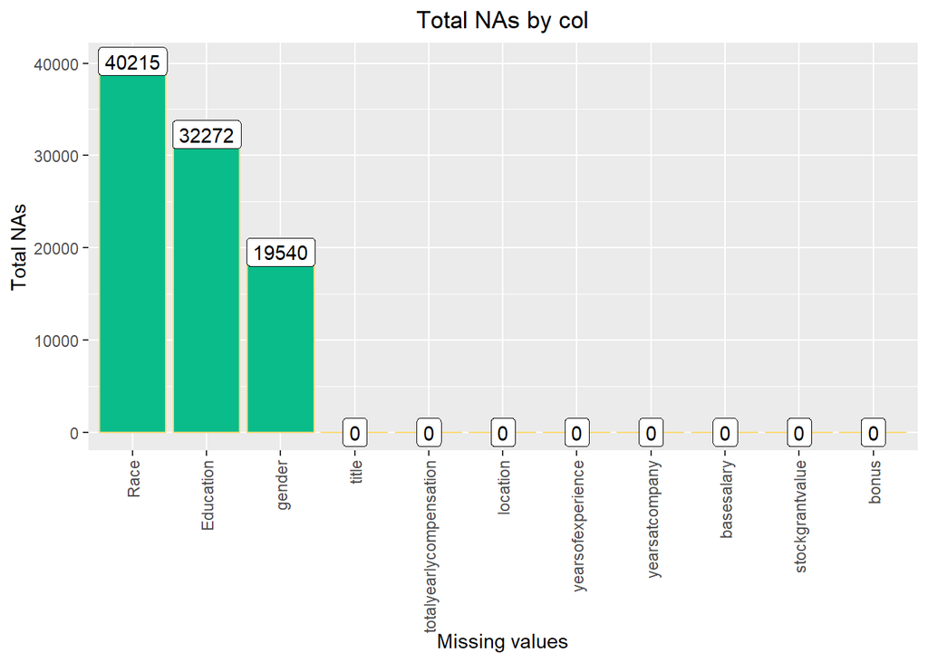

```r
null_df$variable = factor(null_df$variable,
levels = null_df$variable[order(null_df$total_null,decreasing = TRUE)])

ggplot(null_df,aes(x=variable,y=total_null))+ geom_bar(stat = "identity", col = "#FFD972", fill = "#09BC8A")+ theme(axis.text.x = element_text(angle = 90, hjust =1, vjust = 0.5))+
geom_label(aes(label = total_null, size = NULL), nudge_y = 0.7)+
theme(plot.title = element_text(hjust = 0.5))+
ggtitle("Total NAs by col")+
xlab("Missing values") + ylab("Total NAs")
```

```r
missing = is.na(data)
sum(missing)
```

```
## [1] 92027
```

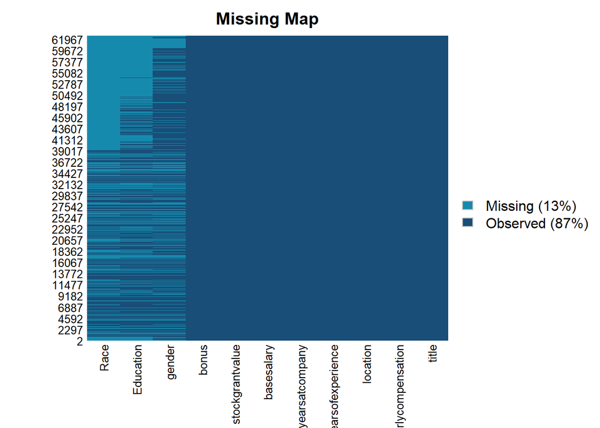

```r
missmap(data, main = 'Missing Map', col = c('#168AAD', '#184e77'))
```

Conclusion: Our NAs are very concentrated in three variables: Race, Education and Gender. Taking into account that missing values represent around 13% of our data base, removing them straight is something we should consider carefully by first evaluating other ideas.

-We may use mice package to predict, or imputation by the median (simple imputation), or regression to predict the NAs.

-As we haven’t studied yet the r^2, we will not use regression. Regarding computing the median, our missing data are factors, so it won’t work.

-I tried with mice, that is a multiple variability method and captures better the variability, as well as having a different method for each type of variable (categorical, numerical, …) to be more precise. Unfortunately, it was extremely CPU-consuming and I could not make it to the end.

```r
#1. basic configuration
#init = mice(data, maxit=0)
#meth = init$method
#predM = init$predictorMatrix

#2.do not predict with these variables (not correlated with the terms we want to predict)
#predM[, c("title")]=0
#predM[, c("location")]=0

#3. do not predict these variables, instead use them as predictors
#meth[c("totalyearlycompensation")]=""
#meth[c("yearsofexperience")]=""
#meth[c("yearsatcompany")]=""
#meth[c("basesalary")]=""
#meth[c("stockgrantvalue")]=""
#meth[c("bonus")]=""

#mice.obj=mice(data[,c(9,10,11)], method = 'rf')
#mice.obj.imp=mice::complete(mice.obj)
#data$Race_prediction = mice.obj.imp$Race
```

```r
data2 = na.omit(data)
```

In conclusion, the best idea would be to remove them straight, because if I computed the percentages in which is factor is present in the variable and considered it is the more likely to be the NA, I would introduce considerable bias in the data, and with approximately 22000 observations we can still make a good job without losing power.

###More graphs

Let’s visualize some information regarding our data set:

First, we have the theory that a distribution implicating salary and experience would have a low bias, and the relationship would be “linear”: the more experience, the better remuneration. From our violin we can say that data science positions in tech are recent, as most of our data belong to the bottom part of the graph, and the outliers at the top are scarce. Also we can exctract that the professionals whose salary is better are recent seniors (professionals who are not as new as juniors, but do not reunite 10 years of experience either).

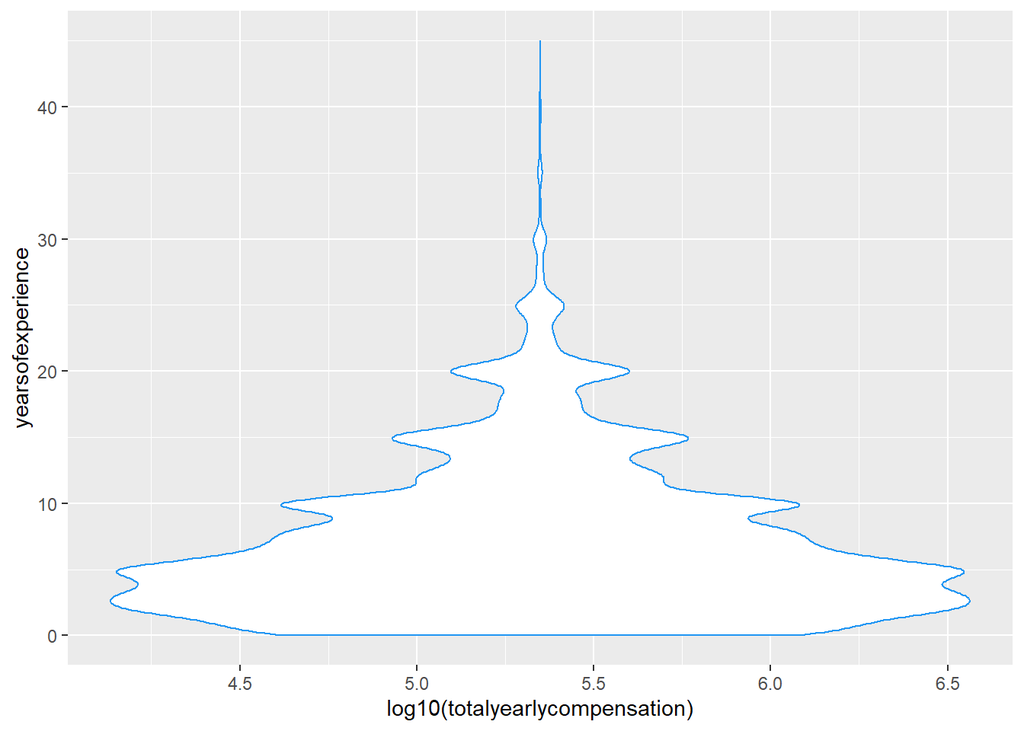

```r
ggplot(data2, aes(x=log10(totalyearlycompensation), y=yearsofexperience)) + # fill=name allow to automatically dedicate a color for each group
  geom_violin(color = "#2196f3")
```

Regarding the race and education, we would like to know if there exists bias regarding race or gender:

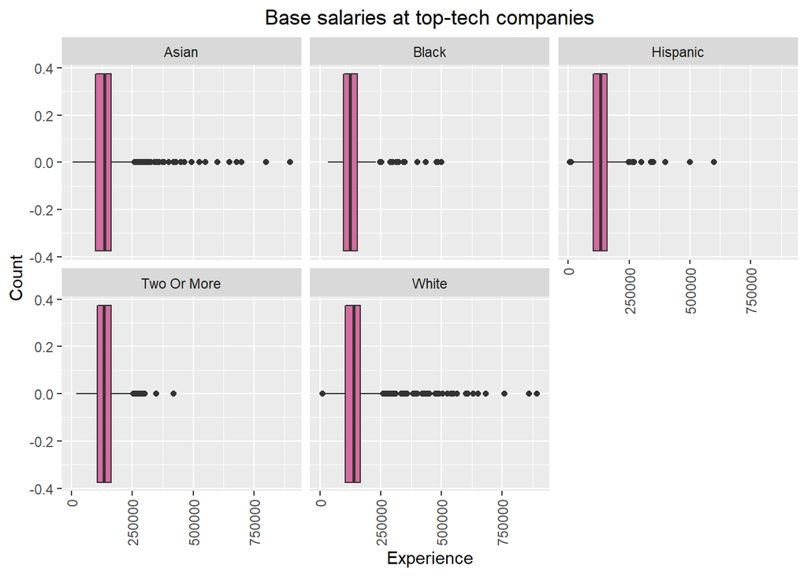

```r
ggplot(data2,aes(x=basesalary))+
  geom_boxplot(fill = "#D66BA0")+
  facet_wrap(~Race)+
  ggtitle("Base salaries at top-tech companies")+
  theme(axis.text.x = element_text(angle = 90, hjust =1, vjust = 0.5))+
  theme(plot.title = element_text(hjust = 0.5))+
  xlab("Experience")+
  ylab("Count")
```

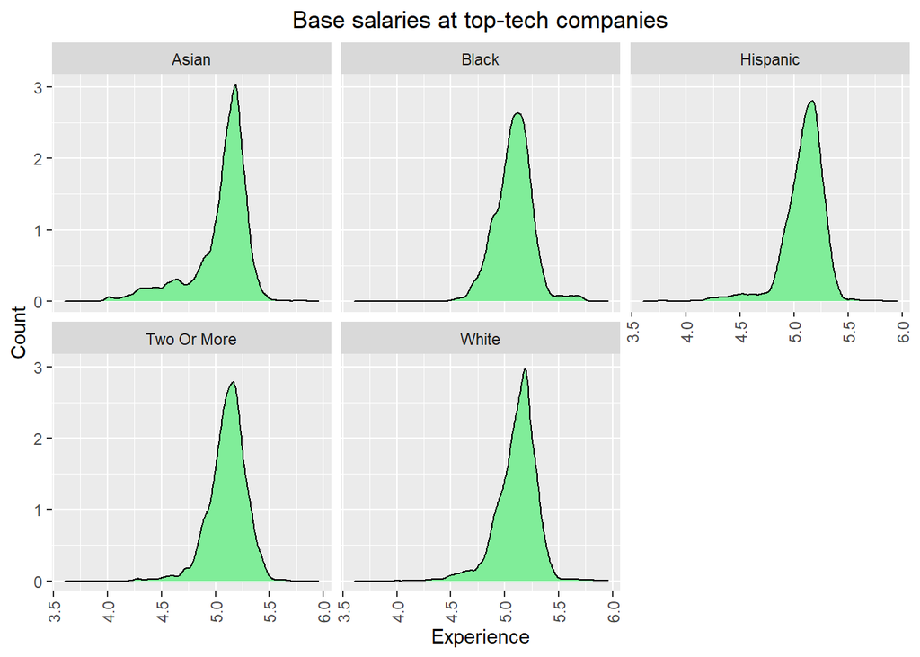

```r
ggplot(data2,aes(x=log10(basesalary)))+
  geom_density(fill = "#80ed99")+
  facet_wrap(~Race)+
  ggtitle("Base salaries at top-tech companies")+
  theme(axis.text.x = element_text(angle = 90, hjust =1, vjust = 0.5))+
  theme(plot.title = element_text(hjust = 0.5))+
  xlab("Experience")+
  ylab("Count")
```

Now let’s check another theory: in companies where the price of stock is higher, base salaries (without productivity bonus) will be higher too. Let’s check that out to confirm so:

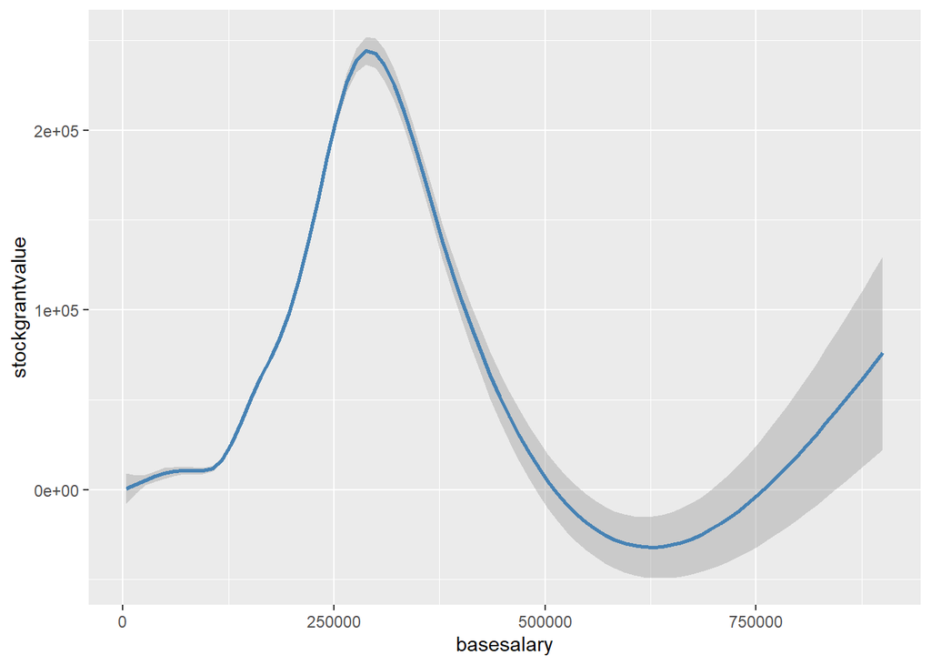

```r
ggplot(data2, aes(x = basesalary, y = stockgrantvalue)) +geom_smooth(colour = 'steelblue')
```

The behaviour is not exactly as we expected; there is a shift in the medium-high base salaries in which the price of stock falls suddenly.

###Formating variables Usually, statistical and machine learning tools require the predictors to be in numeric encoding. An example is linear regression, that requires numbers to assign slopes to the predictors.

For this reason, we will make a copy of our original dataset with numeric format:

```r
data_num = data2
```

```r
data_num$title = NULL
data_num$totalyearlycompensation = as.numeric(data_num$totalyearlycompensation)
data_num$location = NULL
data_num$gender = as.numeric(as.factor(data_num$gender))
data_num$Race = as.numeric(as.factor(data_num$Race))
data_num$Education = as.numeric(as.factor(data_num$Education))
```

###Study on correlation

Now let’s focus on correlation:

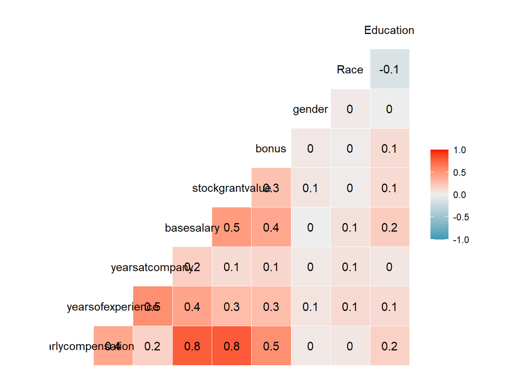

```r
 ggcorr(data_num, label = T)
```

Now let’s see graphically which are the most correlated variables with the one we will try to predict, the total salary in a year.

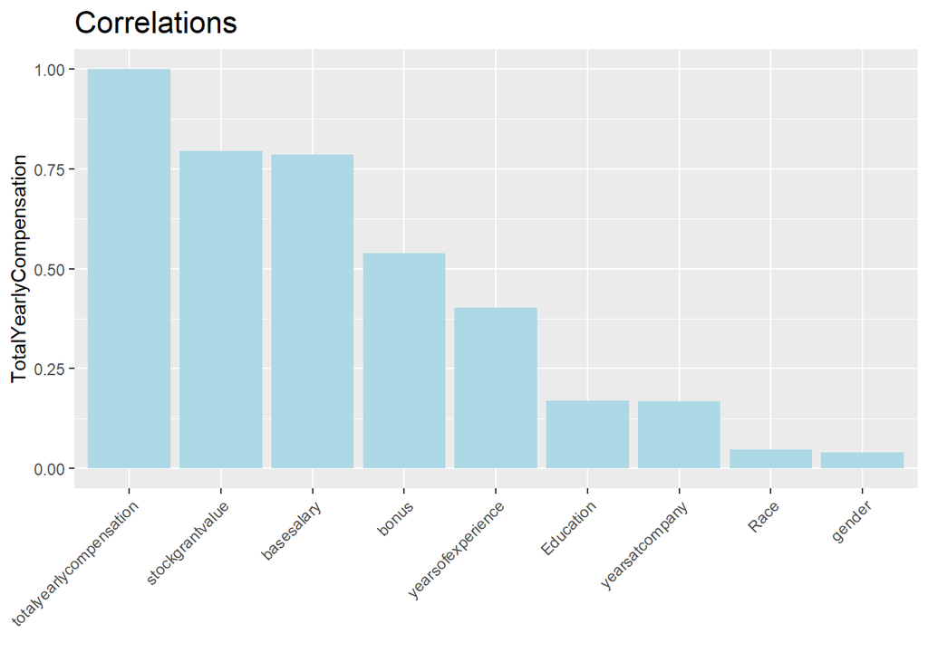

```r
corr_compensation = sort(cor(data_num)["totalyearlycompensation",], decreasing = T)
corr=data.frame(corr_compensation)
ggplot(corr,aes(x = row.names(corr), y = corr_compensation)) +
  geom_bar(stat = "identity", fill = "lightblue") +
  scale_x_discrete(limits= row.names(corr)) +
  labs(x = "", y = "TotalYearlyCompensation", title = "Correlations") +
  theme(plot.title = element_text(hjust = 0, size = rel(1.5)),
        axis.text.x = element_text(angle = 45, hjust = 1))
```

The fact that we have base salary (strongly correlated) and my variables are very correlated with each other may be another reason that explains why the outcome is easy to predict.

**Outliers:**

Outliers are extreme values that are far from the rest of the values.

This is called *univariate identification*. There are other useful univariate tools:

Identification by *IQR*: IQR is a dispersion measure that shows the difference between the third and the first quartile.

```r
QI = quantile(data_num$totalyearlycompensation, 0.25)
QS = quantile(data_num$totalyearlycompensation, 0.75)
IQR = QS-QI

sum(data_num$totalyearlycompensation < QI - 1.5*IQR | data_num$totalyearlycompensation > QS + 1.5*IQR)
```

```
## [1] 990
```

*It is important to remark that due to the big amount of observations that are stored in each of the three groups of salaries, and clearly due to the very predictable distribution my data has (see density plot), accuracies are usually very high*. Although it is an internal characteristic of the data base, we discuss about it in the report too.

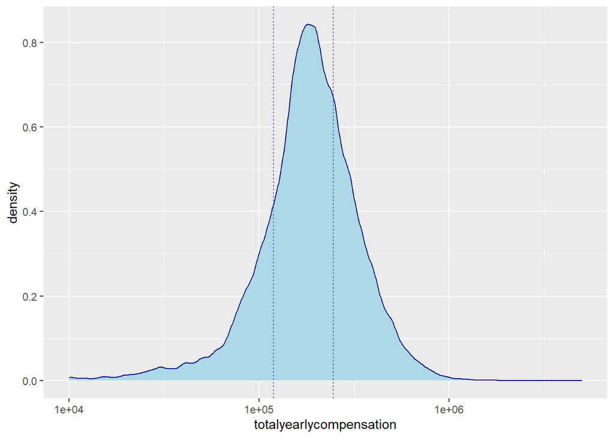

```r
ggplot(data, aes(x=totalyearlycompensation))+
  geom_density(color="darkblue", fill="lightblue")+
  geom_vline(aes(xintercept=QI),
            color="blue", linetype="dashed", size=0.2) +
  geom_vline(aes(xintercept=QS),
            color="blue", linetype="dashed", size=0.2) +
  scale_x_continuous(trans = scales::log_trans(),
                     breaks = scales::log_breaks())
```

The conclusions we can draw form this density plot are that we don’t have a lot of bias and we can say our data are relatively symmetric. We have the expected distribution.

Second, we have computed the number of values in the variable totalyearlycompensation that are outliers (on the left or right), which are 990 out of 21591 (less than 5% of the total observations are that extreme).

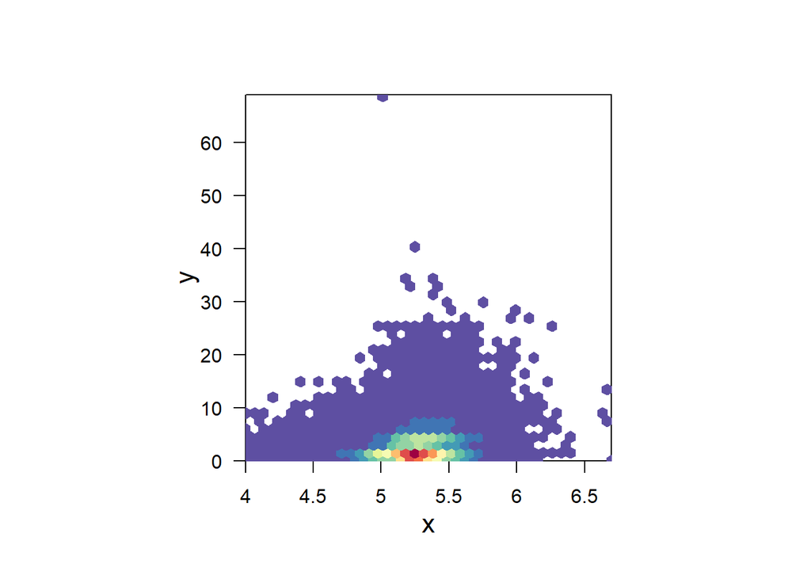

```r
# Create data
x = log10(data$totalyearlycompensation)
y = data$yearsatcompany

# Make the plot
bin=hexbin(x, y, xbins=40)
my_colors=colorRampPalette(rev(brewer.pal(11,'Spectral')))
plot(bin, main="" , colramp=my_colors , legend=F )
```

###Classification In this part of the project I will try many different methods and techniques to check which is the optimal model to predict, using the already created data base in numeric format. Later, we will compare our results. Let’s get started!

# The classification approach

Let’s now divide the Total Yearly Compensation variable in just three categories based on the quantiles we computed previously:

- High
- Average
- Low

```r
data3 = data_num
# Create the three groups or categories (labels)
data3$totalyearlycompensation = factor(ifelse(data2$totalyearlycompensation == QI, "Low", ifelse(data2$totalyearlycompensation >= QS, "High", "Average")))

levels(data3$totalyearlycompensation)
```

```
## [1] "Average" "High"    "Low"
```

```r
# split training and testing sets (80% and 20%)
spl = createDataPartition(data3$totalyearlycompensation, p = 0.8, list = FALSE)  #

comp_train = data3[spl,]
comp_test = data3[-spl,]

str(comp_train)
```

```
## 'data.frame':    17273 obs. of  9 variables:
##  $ totalyearlycompensation: Factor w/ 3 levels "Average","High",..: 2 1 2 1 2 1 2 1 1 1 ...
##  $ yearsofexperience      : num  5 3 6 4 15 3 19 1 5 4 ...
##  $ yearsatcompany         : num  5 2 6 4 3 3 7 1 1 1 ...
##  $ basesalary             : num  210000 124000 177000 164000 160000 103000 160000 130000 140000 150000 ...
##  $ stockgrantvalue        : num  145000 1000 125000 38000 150000 0 460000 30000 62000 60000 ...
##  $ bonus                  : num  45000 11000 36000 20000 0 10000 0 20000 10000 0 ...
##  $ gender                 : num  2 2 2 2 2 2 2 2 2 2 ...
##  $ Race                   : num  1 4 1 1 1 3 1 1 2 3 ...
##  $ Education              : num  4 1 1 3 1 1 1 1 5 2 ...
##  - attr(*, "na.action")= 'omit' Named int [1:41051] 1 2 3 4 5 6 7 8 9 10 ...
##   ..- attr(*, "names")= chr [1:41051] "1" "2" "3" "4" ...
```

## LDA and QDA

LDA (Linear Discriminant Analysis) is used when a linear boundary is required between classifiers and QDA (Quadratic Discriminant Analysis) is used to find a non-linear boundary between classifiers. Due to our big input database, I do not expect big results.

```r
lda.model = lda(totalyearlycompensation ~ ., data=comp_train)
```

Now we have the probabilities:

```r
probability = predict(lda.model, newdata=comp_test)$posterior
head(probability)
```

```
##          Average        High          Low
## 23536 0.96956906 0.029365745 0.0010651935
## 23542 0.99404437 0.002939715 0.0030159121
## 23557 0.99156019 0.005512706 0.0029271047
## 23560 0.25489379 0.744541198 0.0005650164
## 23589 0.05899582 0.940808583 0.0001956021
## 23591 0.99277311 0.002865044 0.0043618464
```

```r
roc.lda = roc(comp_test$totalyearlycompensation,probability[,2])
auc(roc.lda)
```

```
## Area under the curve: 0.9983
```

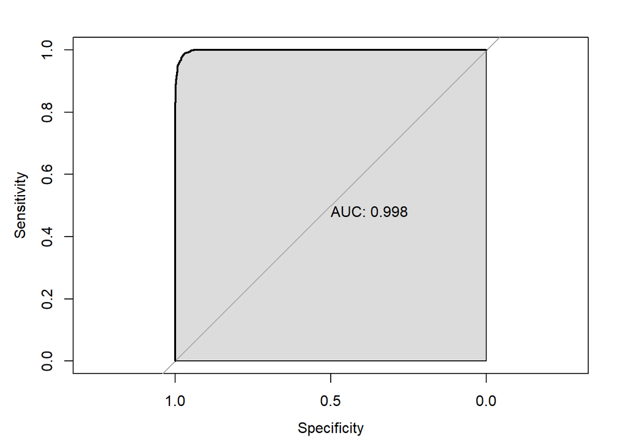

```r
plot.roc(comp_test$totalyearlycompensation,probability[,2], print.auc = TRUE,  auc.polygon=TRUE)
```

AUD = Area Under the Curve: 0.9982, the larger the better. Maximum is 1.

ROC curve shows true positives vs false positives in relation with different thresholds:

- y-axis = Sensitivity (TP)
- x-axis = Specificity (1-FP)

Now we want to predict the labels for our variable by applying the maximum probability of Bayes rule:

```r
prediction = predict(lda.model, newdata=comp_test)$class
head(prediction)
```

```
## [1] Average Average Average High    High    Average
## Levels: Average High Low
```

To check the performance we have the confusion matrix: the predictions are in rows, true values in columns.

```r
confusionMatrix(prediction, comp_test$totalyearlycompensation)$table
```

```
##           Reference
## Prediction Average High  Low
##    Average    3219  344    9
##    High          0  745    0
##    Low           1    0    0
```

```r
confusionMatrix(prediction, comp_test$totalyearlycompensation)$overall[1]
```

```
##  Accuracy
## 0.9180176
```

We have a little bit of overfiting, so we can have a better method for predictions. It is a good point to start, but we can get a better performance classifier.

Now let’s check QDA:

```r
qda.model = qda(totalyearlycompensation ~ ., data=comp_train, prior = c(1/6, 1/3, 1/2))
qda.model
```

```
## Call:
## qda(totalyearlycompensation ~ ., data = comp_train, prior = c(1/6,
##     1/3, 1/2))
##
## Prior probabilities of groups:
##   Average      High       Low
## 0.1666667 0.3333333 0.5000000
##
## Group means:
##         yearsofexperience yearsatcompany basesalary stockgrantvalue     bonus
## Average          5.893012       2.424068   113475.7        17414.98 12260.792
## High            10.910489       3.525591   194661.0       127248.72 36818.453
## Low              8.805556       4.166667   101277.8        11138.89  6583.333
##           gender     Race Education
## Average 1.814752 2.634006  1.961957
## High    1.860225 2.752812  2.295387
## Low     1.833333 3.138889  2.166667
```

Performance:

```r
prediction = predict(qda.model, newdata=comp_test)$class
confusionMatrix(prediction, comp_test$totalyearlycompensation)$table
```

```
##           Reference
## Prediction Average High  Low
##    Average    2874   75    1
##    High        285 1014    0
##    Low          61    0    8
```

```r
confusionMatrix(prediction, comp_test$totalyearlycompensation)$overall[1]
```

```
##  Accuracy
## 0.9022696
```

## A benchmark model

```r
table(comp_train$totalyearlycompensation)
```

```
##
## Average    High     Low
##   12880    4357      36
```

```r
obs = max(table(comp_test$totalyearlycompensation))
# Accuracy:
obs/nrow(comp_test)
```

```
## [1] 0.7457156
```

### Naive-Bayes classification

The Naïve-Bayes (NBC) classifier algorithm is a simple probabilistic classifier with a strong assumption of independence. Although the attribute independence assumption is generally a poor assumption and is often violated by true data sets.

The standard version of Naive-Bayes (in e1071::naiveBayes) assumes independence of the predictor variables, and Gaussian distribution (given the target class) of metric predictors.

```r
#spl = sample(1:nrow(data3), 12000)
#train_1 = data_num[spl,]
#test_1 = data_num[-spl,]
#train_2 = data3[spl,]
#test_2 = data3[-spl,]
```

```r
#na1 = naiveBayes(totalyearlycompensation ~ ., data = comp_train)
```

```r
#pred.na1 = predict(na1, comp_test)
#confusionMatrix(comp_test$totalyearlycompensation, pred.na1)
```

### Machine Learning classification

A machine learning model is a file that has been trained to recognize certain types of patterns. We train a model over a set of data, providing it an algorithm that it can use to reason over and learn from those data. For now, let’s try Gradient Boosting, SVM, RF and KNN and check out which are the outputs and predictions of our models.

### Random Forests

It creates as many trees on the subset of the data and combines the output of all the trees. In this way it reduces overfitting problem in decision trees and also reduces the variance and therefore improves the accuracy. We will implement Cross-Validation to see if we can get better predictions (mainly because cross-validation ensures all samples will appear in the training and test sets, so 100% of our data will be used at some point for training and for testing)

```r
#ctrl = trainControl( method = 'cv', number = 10)

#rf1 = train(totalyearlycompensation~., data = train_2, method = 'rf',
#             trControl = ctrl, tuneLength = 16)
```

```r
#plot(rf1);rf1$bestTune
#results in the confusion matrix
#confusionMatrix(rf1)
```

```r
#spl = sample(1:nrow(data3), 7000)
#train_1 = data_num[spl,]
#test_1 = data_num[-spl,]
#train_2 = data3[spl,]
#test_2 = data3[-spl,]
```

Let’s check which is the most important variable to classify:

```r
#plot(varImp(rf1))
```

To gain some insight on trees, let’s try this powerful tool individually (even if it loses a little bit of power).

```r
#trees = train(totalyearlycompensation~., data = train_2, method = 'rpart',
#             trControl = ctrl,
#             tuneLength = 20)

#pred = predict(trees, test_2);confusionMatrix(table(test_2[,"totalyearlycompensation"],pred))
```

```r
#print(trees);plot(trees);trees$bestTune
#rpart.plot(trees$finalModel,fallen.leaves = T)
```

```r
#tree1 = rpart(train_2, maxdepth = 5, cp = 0.005)
#rpart.plot(tree1,fallen.leaves = T)
```

```r
#plot(varImp(trees))
```

### KNN

For this model, we will need to scale our data. This is because the distance calculation done in KNN uses feature values. When the one feature values are large than other, that feature will dominate the distance hence the outcome of the KNN.

This is my new train and test set:

```r
#data3 = data_num;
#data3$totalyearlycompensation = NULL
#data3 = scale(data3)
```

```r
#data3 = cbind(data3, data_num[,"totalyearlycompensation"])
#data3 = as.data.frame(data3)
#colnames(data3)[9] = 'totalyearlycompensation'
#data3[,9] = as.factor(data3[,9])

#data3$totalyearlycompensation = factor(ifelse(data2$totalyearlycompensation == QI, "Low", ifelse(data2$totalyearlycompensation >= QS, "High", "Average")))
```

Now that we have scaled the data, let’s partition it to train and test the model:

```r
#r.ids  = createDataPartition(data3$totalyearlycompensation, p = 0.5, list = F)
#traink = data3[r.ids, ]; temp = data3[-r.ids, ]
#v.ids = createDataPartition(temp$totalyearlycompensation, p = 0.5, list = F)
#val = temp[v.ids, ]; testk = temp[-v.ids, ]
```

Let’s do again what we did for random forest; first, we saw the “complex” model and later, a basic case. In this case, we will try the simplest version of KNN and see what happens.

```r
#k1 = knn(traink[ ,1:8], val[ ,1:8], traink[,9], k = 1)
#acc = sum(k1 == val$totalyearlycompensation)/length(val$totalyearlycompensation)
#confusionMatrix(table(val$totalyearlycompensation, k1))$byClass
```

```r
#k_grid = expand.grid(k = seq(1,59, 2))
```

```r
#for (i in 1:nrow(k_grid)){
#  k = knn(traink[ ,1:8], val[ ,1:8], traink[,9], k = k_grid$k[i])
#  k_grid$acc[i] = sum(k == val$totalyearlycompensation)/length(val$totalyearlycompensation)
#}
```

```r
#plot(x = k_grid$k, y = k_grid$acc, xlab="K- Value",ylab="Accuracy")
```

### SVM

First of all, we will need to use the same data as in KNN because we are also working with distances. The main difference is that we will give more wight to the testing set and less to the training one:

```r
#t.ids = createDataPartition(data3$totalyearlycompensation, p = 0.7, list = F)
#train_4= data3[t.ids,]
#test_4 = data3[-t.ids,]
```

A simple model before we start with caret:

```r
#s1 = svm(totalyearlycompensation~.,data = train_4)
#pred.s = predict(s1, test_4)

#results
#confusionMatrix(table(test_4$totalyearlycompensation, pred.s))
```

As this is a simple model, let’s see what happens if we tune the parameters: we will use radial, linear en polynomial svm, but it would be also possible to use svmLinearWeights2 model, for example. ************

```r
#svmlinear = train(totalyearlycompensation ~., data = train_4, method = "svmLinear", trControl = ctrl,  preProcess = c("center","scale"), tuneGrid = expand.grid(C = seq(0, 1, length = 20)))
#pred_svmlinear = predict(svmlinear, test_4)
#results and plot
#confusionMatrix(table(test_4$totalyearlycompensation, pred_svmlinear))
#plot(svmlinear)
```

Now let’s try with one that I think will fit better, radial kernel (for non-linear data).The right kernel function has to be chosen as the kernel-function defines the hyperplane.

```r
#svmradial = train(totalyearlycompensation ~., data = train_4, method = "svmRadial", trControl = ctrl, preProcess = c("center","scale"), tuneLength = 10)

#predictionsvmradial = predict(svmradial, test_4)
#confusionMatrix(table(test_4$totalyearlycompensation, predictionsvmradial))

#plot(svmradial)
#svmradial$bestTune
```

```r
#svmpol = train(totalyearlycompensation ~., data = train_4, method = "svmPoly", trControl = ctrl, preProcess = c("center","scale"), tuneLength = 10)

#predictionsvmpol = predict(svmpol, test_4)
#confusionMatrix(table(test_4$totalyearlycompensation, predictionsvmradial))

#plot(svmpol)
#svmpol$bestTune
```

```r
#grodboost_grid = expand.grid(
#  nrounds = c(500,1000),
#  eta = c(0.01, 0.001),
#  max_depth = c(2, 4, 6),
#  gamma = 1,
#  colsample_bytree = c(0.2, 0.4),
#  min_child_weight = c(1,5),
#  subsample = 1)
```

```r
#gradboost1 = train(totalyearlycompensation ~ .,  data=train_2,
#                  trControl = ctrl,
#                  maximize = F,
#                  tuneGrid = grodboost_grid,
#                  preProcess = c("center", "scale"),
#                  method = "xgbTree"
#)
```

```r
#predictions for the model
#pred_3 = predict(xgb1, test_2)
#confusionMatrix(table(test_2[,"TotalYearlyCompensation"],pred_3))
```

```r
#xgb_imp = varImp(xgb1, scale = F)
#plot(xgb_imp, scales = list(y = list(cex = .95)))
```

### Logistic regression

Some assumptions we need to take into consideration are that the mean of error is zero or the predicted variables follow a normal distribution (which, for our data, is not that close from reality).

```r
#Obviously, I am using now my numerical dataset
#i_t = createDataPartition(data_num$totalyearlycompensation, p = 0.75, list = FALSE)
#train_reg1 = data_num[ i_t,]
#test_reg1 = data_num[-i_t,]
```

We will be following a simple-to-complex process. The second thing we will do is to establish the correlations again.

Using the first correlation plot:

```r
#ggcorr(data_num, label = T)
```

The results are predictable, we had the same in classification.

### Monovariable simple model

```r
#msl = lm(formula = totalyearlycompensation ~ bonus, data = train_reg1)
```

```r
#perfsl = predict(msl, newdata=test_reg1)
#cor(test_reg1$totalyearlycompensation, perfsl)^2
```

```r
#effect_plot(msl, pred = bonus , interval = TRUE, plot.points = TRUE)
```

### Simple non-linear model

```r
#msl2 = lm(formula = totalyearlycompensation ~ I(bonus^2), data = train_reg1)
```

```r
#prsl2 = sqrt(predict(msl2, newdata=test_reg1))
#cor(test_reg1$totalyearlycompensation, prsl2)^2
```

```r
#effect_plot(msl2, pred = bonus , interval = TRUE, plot.points = TRUE)
```

### Multivariate simple model

We select as predictors the ones with bigger correlations in the corrpolot we had:

```r
#msm = lm(totalyearlycompensation ~ I(bonus^2) + I(basesalary^2) + I(stockgrantvalue^2), data=train_reg1)
#summary(msm)
```

```r
#prsm = sqrt(predict(msm, newdata=test_reg1))
#cor(test_reg1$totalyearlycompensation, prsm)^2
#RMSE = sqrt(mean((prsm - test_reg1$totalyearlycompensation)^2))
#RMSE
```

What would happen if we try the model with more variables?

```r
#msm2 = lm(totalyearlycompensation ~ I(bonus^2) + I(basesalary^2) + I(stockgrantvalue^2) + I(yearsofexperience^2) + I(yearsatcompany^2) + I(gender^2) +I(Education^2), data=train_reg1)
#summary(msm2)
```

```r
#simple benchmark
#mean(train_reg1$totalyearlycompensation)

#benchFit = lm(totalyearlycompensation ~ 1, data=train_reg1)
#predictions = predict(benchFit, newdata=test_reg1)
#RMSE = sqrt(mean((predictions - test_reg1$totalyearlycompensation)^2))
#RMSE
```

### Linear model using Caret

```r
#LM = totalyearlycompensation ~ I(bonus^2) + I(basesalary^2) +   I(stockgrantvalue^2) + I(yearsofexperience^2) + I(yearsatcompany^2) + I(gender^2) +I(Education^2)

#lm_tuning = train(LM, data = train_reg1, method = "lm", preProc=c('scale', 'center'),trControl = ctrl)

#lm_tuning
```

```r
#test_res = data.frame(totalyearlycompensation = test_reg1$totalyearlycompensation)
#test_res$lm = predict(lm_tuning, test_reg1)
#postResample(pred = test_res$lm,  obs = test_res$totalyearlycompensation)
```

These numbers are not very comfortable to read, so we better plot the model to decide:

```r
#qplot(test_res$lm, test_res$totalyearlycompensation) +
#  labs(title="Linear Regression", x="Predictions", y="Observations") +
#  geom_abline(intercept = 0, slope = 1, colour = "#2a9d8f") +
#  theme_bw()
```

### Regression with leap forward

```r
#library(leaps)
#forw_tune = train(LM, data = train_reg1,
#                  method = "leapForward",
#                  preProc=c('scale', 'center'),
#                  tuneGrid = expand.grid(nvmax = 3:8),
#                  trControl = ctrl)

#forw_tune
#plot(forw_tune)
```

What variables will be selected to do this regression? Let’s take that insight.

```r
#coef(forw_tune$finalModel, forw_tune$bestTune$nvmax)
```

### Second model, different formula

This formula is slightly more similar to the actual formula for IPF, this is a non linear model (more complex). I suppose R^2 will get worse as dimensionality gets higher, in this case, so elaborating this model is counterproductive, but let’s see what happens in such case.

```r
#LM2 = totalyearlycompensation ~ gender*((I(bonus^2) + I(basesalary^2) + I(stockgrantvalue^2) + I(yearsatcompany^2)))/exp(-yearsofexperience)
```

hope I don’t improve my data with this nonlinear model.I

```r
#forw_tune2 = train(LM2, data = train_reg1, method = "leapForward", tuneGrid = expand.grid(nvmax = 3:8), trControl = ctrl)

#forw_tune2
```

It is not worth it to keep adding predictors to our model if the ones that are left don’t gather valuable information.

### Ridge regression

Ridge regression is a model tuning method that is used to analyse any data that suffers from multicollinearity. This method performs L2 regularization. When the issue of multicollinearity occurs, least-squares are unbiased, and variances are large, this results in predicted values being far away from the actual values.

A grid for the hypertunning:

```r
#grid_hyper = expand.grid(lambda = seq(0, .1, .001))
```

Creating the first model:

```r
#ridge_1 = train(LM, data = train_reg1,
#                    method='ridge',
#                    preProc=c('scale','center'),
#                    tuneGrid = grid_hyper,
#                    trControl=ctrl)
```

Seeing what the best tune for the model is:

```r
#plot(ridge_1)
#ridge_1$bestTune
```

```r
#test_res$ridge_1 = predict(ridge_1, test_reg1)

#postResample(pred = test_res$ridge,  obs = test_res$totalyearlycompensation)
```

Let’s apply the same technique to our second model:

```r
#ridge_2 = train(LM2, data = train_reg1  ,
#                    method='ridge',
#                    preProc=c('scale','center'),
#                    tuneGrid = grid_hyper,
#                    trControl=ctrl)
```

Seeing what the best tune for the model is:

```r
#plot(ridge_2)
#ridge_2$bestTune


#test_res$ridge_2 = predict(ridge_2, test_reg1)

#postResample(pred = test_res$ridge_2,  obs = test_res$totalyearlycompensation)
```

### LASSO

Lasso regression is a type of linear regression that uses shrinkage. Shrinkage is where data values are shrunk towards a central point, like the mean. The lasso procedure encourages simple, sparse models (i.e. models with fewer parameters). This particular type of regression is well-suited for models showing high levels of muticollinearity or when you want to automate certain parts of model selection, like variable selection/parameter elimination.

```r
#grid_lasso = expand.grid(fraction = seq(.01, 1, length = 100))
```

For the first model we have the following lines of code.

```r
#lasso_1 = train(LM, data = train_reg1,
#                    method='lasso',
#                    preProc=c('scale','center'),
#                    tuneGrid = grid_lasso,
#                    trControl=ctrl)
```

This is the best fraction, and now we can see (better graphically) the difference between all the graphs

```r
#plot(lasso_1)
#lasso_1$bestTune
```

Final $R^2$ and RMSE

```r
#test_res$lasso_1 = predict(lasso_1, test_reg1)
#postResample(pred = test_res$lasso_1,  obs = test_res$totalyearlycompensation)
```

For the second model

```r
#lasso_2 = train(LM2, data = train_reg1,
#                    method='lasso',
#                    preProc=c('scale','center'),
#                    tuneGrid = grid_lasso,
#                    trControl=ctrl)
```

```r
#plot(lasso_2)
#lasso_2$bestTune
```

```r
#test_res$lasso_2 = predict(lasso_2, test_reg1)
#postResample(pred = test_res$lasso_2,  obs = test_res$totalyearlycompensation)
#the r^2 decreases
```

Last but not least, let’s apply a method that combines the penalization of the previous ones and see which results and conclusions we do get.

### Elastic Net

The elastic net method overcomes the limitations of the LASSO (least absolute shrinkage and selection operator) method which uses a penalty function based on two parameters alpha and lambda.

The first step is to design an adequate grid for it.

```r
#grid_elnet = expand.grid(alpha = seq(0, .2, 0.01), lambda = seq(0, .1, 0.01))
```

```r
#elnet_1 = train(LM, data = train_reg1, method ='glmnet',preProc=c('scale','center'), tuneGrid = grid_elnet ,trControl=ctrl)
```

```r
#elnet_1$bestTune
#test_res$elnet_1 = predict(elnet_1, test_reg1)
#postResample(pred = test_res$elnet_1,  obs = test_res$totalyearlycompensation)
```

```r
#elnet_2 = train(LM2, data = train_reg1, method='glmnet',preProc=c('scale','center'),tuneGrid = grid_elnet,trControl=ctrl)
```

```r
#elnet_2$bestTune
#test_res$elnet_2 = predict(elnet_2, test_reg1)
#postResample(pred = test_res$elnet_2,  obs = test_res$totalyearlycompensation)
```

Let’s compare both models graphically to see the main differences on them:

```r
#plot(elnet_1); plot(el_net2)
```

Elastic net is always preferred over lasso & ridge regression because it solves the limitations of both methods, while also including each as special cases. So if the ridge or lasso solution is, indeed, the best, then any good model selection routine will identify that as part of the modeling process.

```r
#apply(test_res[-1], 2, function(x) mean(abs(x - test_res$totalyearlycompensation)))

#test_res$comb1 = (test_res$ridge_1 + test_res$lasso_1 + test_res$elnet_1)/3
#test_res$comb2 = (test_res$ridge_2 + test_res$lasso_2 + test_res$elnet_2)/3

#postResample(pred = test_res$comb1,  obs = test_res$totalyearlycompensation)
#postResample(pred = test_res$comb2,  obs = test_res$totalyearlycompensation)
```

### Conclusion

After all the work, I think I have understood (or at least figured out) more about modelling and regression. One thing I did not expect about my data base is the linearity it has, it is easy to predict and easy to fit into different models because of the internal correlations. Thanks to this characteristic, I have made huge research on techniques to avoid overfiting and underfiting (including ones that integrate Python or TensorFlow), and on high-accuracies interpretation. Finally, I think that the most valuable content I am taking from this project are the ideas below each model, how to interpret it depending on the data you are given and how the different errors look like. I am sure I will be applying all these knowledge in the future for more advanced data science techniques, and I feel like my skills have evolved a little bit further, making me feel closer to my future job as a data scientist.

### References

Manas, A. Beginning data science with R

R Graphics Cookbook

https://www.cienciadedatos.net/documentos/41_machine_learning_con_r_y_caret#Selecci%C3%B3n_de_predictores

https://search.r-project.org/CRAN/refmans/pacviz/html/svm.partition.html

https://rdrr.io/github/rstudio/keras/man/layer_dropout.html

https://www.aprendemachinelearning.com/clasificacion-con-datos-desbalanceados/

https://rpubs.com/uky994/593668

https://youtu.be/2zKPiBSIlZ4

https://youtu.be/2zKPiBSIlZ4